# Krzysztof Tomala - Explainable AI - Homework 4

# List of features with short descriptions and possible values of categorical variables

Age  
Workclass: Private, Self-emp-not-inc, Self-emp-inc, Federal-gov, Local-gov, State-gov, Without-pay, Never-worked  
fnlwgt: the number of units in the target population that the responding unit represents  
education: Bachelors, Some-college, 11th, HS-grad, Prof-school, Assoc-acdm, Assoc-voc, 9th, 7th-8th, 12th, Masters, 1st-4th, 10th, Doctorate, 5th-6th, Preschool  
education-num: repetitive variable which recodes the categorical variable education as a numeric variable  
marital-status: Married-civ-spouse, Divorced, Never-married, Separated, Widowed, Married-spouse-absent, Married-AF-spouse  
occupation: Tech-support, Craft-repair, Other-service, Sales, Exec-managerial, Prof-specialty, Handlers-cleaners, Machine-op-inspct, Adm-clerical, Farming-fishing, Transport-moving, Priv-house-serv, Protective-serv, Armed-Forces  
relationship: Wife, Own-child, Husband, Not-in-family, Other-relative, Unmarried  
race: White, Asian-Pac-Islander, Amer-Indian-Eskimo, Other, Black  
sex: Female, Male  
capital-gain  
capital-loss  
hours-per-week  
native-country: United-States, Cambodia, England, Puerto-Rico, Canada, Germany, Outlying-US(Guam-USVI-etc), India, Japan, Greece, South, China, Cuba, Iran, Honduras, Philippines, Italy, Poland, Jamaica, Vietnam, Mexico, Portugal, Ireland, France, Dominican-Republic, Laos, Ecuador, Taiwan, Haiti, Columbia, Hungary, Guatemala, Nicaragua, Scotland, Thailand, Yugoslavia, El-Salvador, Trinadad&Tobago, Peru, Hong, Holand-Netherlands

# Tasks

```
For the selected protected attribute (age, gender, race) calculate the following fairness coefficients: Statistical parity, Equal opportunity, Predictive parity.
```

[figure not shown]

I have decided to use the classification random forest with default parametrs trained to predict probability that the income of a person is greater then 50k. The protected variable I am using is sex.  
As we can see on the plots, the Equal opportunity ratio and Predictive parity ratio fit into (0.8,1.25) interval, but Statistical parity ratio is lower then 0.3, which means that our model is biased agains woman.

```
Train another model (different hyperparameters, feature transformations etc.) and see how the coefficients Statistical parity, Equal opportunity, Predictive parity behave for it.
```

[figure not shown]

The second model that I am using is the logistic regression with default parametrs. I am using the same data and protected variable.  
Here we can see that the Statistical parity ration is even smaller then for the random forest and Predictive parity ratio and Equal opportunity ratio both does not fit into (0.8, 1.25) interval anymore, which means that this model is more biased then the one we had before.

```
Apply the selected bias mitigation technique on the first model. Check how Statistical parity, Equal opportunity, Predictive parity coefficients behave after this correction.
```

[figure not shown]

I am using resampling method to mitigate the bias in random forest.  
Now we can see that all of the check that we are checking are not in the interval (0.8, 1.25), but this time the Statistical parity ratio is much closer to 1.0 than it was, so we can see, that we are able to get close to fixing on of the fairness checks, but the tradeof is that we need to sacrifice some of the other ones.

```
Compare the quality (performance) of the three models with their fairness coefficients. Is there any correlation?
```

[figure not shown]

We can see that the logistic regressing is the worst of 3 algorithms in terms of performance, and I would say that forest is beating the forest with bias mitigation, but they are very close.  
When it comes to comparing this to fairness coefficients we can see, that to increase the statistical parity ratio random forest had to sacrifice a loss of recall, but the statistical parity ratio is lower for logistic regression then for the random forest, so I don't think that there are any general conclusions.

# Appendix

```python
import dalex as dx
import xgboost

import sklearn
from sklearn.model_selection import train_test_split
import sklearn.ensemble

import pandas as pd
import numpy as np

import warnings
warnings.filterwarnings("ignore")

import platform
print(f'Python {platform.python_version()}')

{package.__name__: package.__version__ for package in [dx, xgboost, sklearn, pd, np]}
```

```
Python 3.9.12
```

```
{'dalex': '1.5.0',
 'xgboost': '1.7.1',
 'sklearn': '1.0.2',
 'pandas': '1.4.2',
 'numpy': '1.21.5'}
```

```python
dataset = pd.read_csv('adult.csv')
print(dataset.columns)
dataset = dataset.dropna()
dataset = pd.get_dummies(dataset)
dataset
```

```
Index(['age', 'workclass', 'fnlwgt', 'education', 'educational-num',
       'marital-status', 'occupation', 'relationship', 'race', 'gender',
       'capital-gain', 'capital-loss', 'hours-per-week', 'native-country',
       'income'],
      dtype='object')
```

|  | age | fnlwgt | educational-num | capital-gain | capital-loss | hours-per-week | workclass_? | workclass_Federal-gov | workclass_Local-gov | workclass_Never-worked | ... | native-country_Scotland | native-country_South | native-country_Taiwan | native-country_Thailand | native-country_Trinadad&Tobago | native-country_United-States | native-country_Vietnam | native-country_Yugoslavia | income_<=50K | income_>50K |
| --- | --- | --- | --- | --- | --- | --- | --- | --- | --- | --- | --- | --- | --- | --- | --- | --- | --- | --- | --- | --- | --- |
| 0 | 25 | 226802 | 7 | 0 | 0 | 40 | 0 | 0 | 0 | 0 | ... | 0 | 0 | 0 | 0 | 0 | 1 | 0 | 0 | 1 | 0 |
| 1 | 38 | 89814 | 9 | 0 | 0 | 50 | 0 | 0 | 0 | 0 | ... | 0 | 0 | 0 | 0 | 0 | 1 | 0 | 0 | 1 | 0 |
| 2 | 28 | 336951 | 12 | 0 | 0 | 40 | 0 | 0 | 1 | 0 | ... | 0 | 0 | 0 | 0 | 0 | 1 | 0 | 0 | 0 | 1 |
| 3 | 44 | 160323 | 10 | 7688 | 0 | 40 | 0 | 0 | 0 | 0 | ... | 0 | 0 | 0 | 0 | 0 | 1 | 0 | 0 | 0 | 1 |
| 4 | 18 | 103497 | 10 | 0 | 0 | 30 | 1 | 0 | 0 | 0 | ... | 0 | 0 | 0 | 0 | 0 | 1 | 0 | 0 | 1 | 0 |
| ... | ... | ... | ... | ... | ... | ... | ... | ... | ... | ... | ... | ... | ... | ... | ... | ... | ... | ... | ... | ... | ... |
| 48837 | 27 | 257302 | 12 | 0 | 0 | 38 | 0 | 0 | 0 | 0 | ... | 0 | 0 | 0 | 0 | 0 | 1 | 0 | 0 | 1 | 0 |
| 48838 | 40 | 154374 | 9 | 0 | 0 | 40 | 0 | 0 | 0 | 0 | ... | 0 | 0 | 0 | 0 | 0 | 1 | 0 | 0 | 0 | 1 |
| 48839 | 58 | 151910 | 9 | 0 | 0 | 40 | 0 | 0 | 0 | 0 | ... | 0 | 0 | 0 | 0 | 0 | 1 | 0 | 0 | 1 | 0 |
| 48840 | 22 | 201490 | 9 | 0 | 0 | 20 | 0 | 0 | 0 | 0 | ... | 0 | 0 | 0 | 0 | 0 | 1 | 0 | 0 | 1 | 0 |
| 48841 | 52 | 287927 | 9 | 15024 | 0 | 40 | 0 | 0 | 0 | 0 | ... | 0 | 0 | 0 | 0 | 0 | 1 | 0 | 0 | 0 | 1 |

48842 rows × 110 columns

```python
for c in dataset.columns:
    print(c)
```

```
age
fnlwgt
educational-num
capital-gain
capital-loss
hours-per-week
workclass_?
workclass_Federal-gov
workclass_Local-gov
workclass_Never-worked
workclass_Private
workclass_Self-emp-inc
workclass_Self-emp-not-inc
workclass_State-gov
workclass_Without-pay
education_10th
education_11th
education_12th
education_1st-4th
education_5th-6th
education_7th-8th
education_9th
education_Assoc-acdm
education_Assoc-voc
education_Bachelors
education_Doctorate
education_HS-grad
education_Masters
education_Preschool
education_Prof-school
education_Some-college
marital-status_Divorced
marital-status_Married-AF-spouse
marital-status_Married-civ-spouse
marital-status_Married-spouse-absent
marital-status_Never-married
marital-status_Separated
marital-status_Widowed
occupation_?
occupation_Adm-clerical
```

[output cut: 55 more lines]

```
native-country_Peru
native-country_Philippines
native-country_Poland
native-country_Portugal
native-country_Puerto-Rico
native-country_Scotland
native-country_South
native-country_Taiwan
native-country_Thailand
native-country_Trinadad&Tobago
native-country_United-States
native-country_Vietnam
native-country_Yugoslavia
income_<=50K
income_>50K
```

```python
features = dataset.drop(columns=['income_<=50K','income_>50K'])

features
X_train, X_test, y_train, y_test = sklearn.model_selection.train_test_split(features, dataset['income_>50K'], test_size=0.3, random_state=0)
X_train
```

|  | age | fnlwgt | educational-num | capital-gain | capital-loss | hours-per-week | workclass_? | workclass_Federal-gov | workclass_Local-gov | workclass_Never-worked | ... | native-country_Portugal | native-country_Puerto-Rico | native-country_Scotland | native-country_South | native-country_Taiwan | native-country_Thailand | native-country_Trinadad&Tobago | native-country_United-States | native-country_Vietnam | native-country_Yugoslavia |
| --- | --- | --- | --- | --- | --- | --- | --- | --- | --- | --- | --- | --- | --- | --- | --- | --- | --- | --- | --- | --- | --- |
| 3833 | 27 | 131310 | 10 | 0 | 0 | 40 | 0 | 0 | 1 | 0 | ... | 0 | 0 | 0 | 0 | 0 | 0 | 0 | 1 | 0 | 0 |
| 34743 | 42 | 367533 | 6 | 0 | 0 | 43 | 0 | 0 | 0 | 0 | ... | 0 | 0 | 0 | 0 | 0 | 0 | 0 | 1 | 0 | 0 |
| 2022 | 32 | 38158 | 11 | 7298 | 0 | 70 | 0 | 0 | 0 | 0 | ... | 0 | 0 | 0 | 0 | 0 | 0 | 0 | 1 | 0 | 0 |
| 1580 | 36 | 148903 | 10 | 0 | 0 | 60 | 0 | 0 | 0 | 0 | ... | 0 | 0 | 0 | 0 | 0 | 0 | 0 | 1 | 0 | 0 |
| 4612 | 29 | 359155 | 9 | 0 | 0 | 30 | 0 | 0 | 0 | 0 | ... | 0 | 0 | 0 | 0 | 0 | 0 | 0 | 1 | 0 | 0 |
| ... | ... | ... | ... | ... | ... | ... | ... | ... | ... | ... | ... | ... | ... | ... | ... | ... | ... | ... | ... | ... | ... |
| 21243 | 31 | 153078 | 12 | 0 | 0 | 50 | 0 | 0 | 0 | 0 | ... | 0 | 0 | 0 | 0 | 0 | 0 | 0 | 1 | 0 | 0 |
| 45891 | 60 | 399387 | 4 | 0 | 0 | 15 | 0 | 0 | 0 | 0 | ... | 0 | 0 | 0 | 0 | 0 | 0 | 0 | 1 | 0 | 0 |
| 42613 | 55 | 175942 | 16 | 0 | 1977 | 55 | 0 | 0 | 0 | 0 | ... | 0 | 0 | 0 | 0 | 0 | 0 | 0 | 0 | 0 | 0 |
| 43567 | 29 | 85572 | 7 | 0 | 0 | 5 | 0 | 0 | 0 | 0 | ... | 0 | 0 | 0 | 0 | 0 | 0 | 0 | 1 | 0 | 0 |
| 2732 | 59 | 136819 | 14 | 0 | 0 | 8 | 0 | 0 | 0 | 0 | ... | 0 | 0 | 0 | 0 | 0 | 0 | 0 | 1 | 0 | 0 |

34189 rows × 108 columns

```python
forest = sklearn.ensemble.RandomForestClassifier()
forest.fit(X=X_train,y=y_train)
print(f'Accuracy: {sklearn.metrics.accuracy_score(y_test,forest.predict(X_test))}')
print(f'Recall: {sklearn.metrics.recall_score(y_test,forest.predict(X_test))}')
print(f'Precision: {sklearn.metrics.precision_score(y_test,forest.predict(X_test))}')

forest_accuracy = sklearn.metrics.accuracy_score(y_test,forest.predict(X_test))
forest_recall = sklearn.metrics.recall_score(y_test,forest.predict(X_test))
forest_precision = sklearn.metrics.precision_score(y_test,forest.predict(X_test))

print('\nResults on train dataset:')
print(f'Accuracy: {sklearn.metrics.accuracy_score(y_train,forest.predict(X_train))}')
print(f'Recall: {sklearn.metrics.recall_score(y_train,forest.predict(X_train))}')
print(f'Precision: {sklearn.metrics.precision_score(y_train,forest.predict(X_train))}')
```

```
Accuracy: 0.85415955776974
Recall: 0.6256045519203414
Precision: 0.7281456953642385

Results on train dataset:
Accuracy: 0.9999415016525783
Recall: 0.9997552618697993
Precision: 1.0
```

```python
import numpy as np
predict = lambda m, d: m.predict_proba(d)[:,1]

X = X_test
y = y_test
explainer = dx.Explainer(forest, X_test, y_test, predict_function=predict, label="forest")
```

```
Preparation of a new explainer is initiated

  -> data              : 14653 rows 108 cols
  -> target variable   : Parameter 'y' was a pandas.Series. Converted to a numpy.ndarray.
  -> target variable   : 14653 values
  -> model_class       : sklearn.ensemble._forest.RandomForestClassifier (default)
  -> label             : forest
  -> predict function  : <function <lambda> at 0x7f3909c0b790> will be used
  -> predict function  : Accepts pandas.DataFrame and numpy.ndarray.
  -> predicted values  : min = 0.0, mean = 0.242, max = 1.0
  -> model type        : classification will be used (default)
  -> residual function : difference between y and yhat (default)
  -> residuals         : min = -1.0, mean = -0.00205, max = 1.0
  -> model_info        : package sklearn

A new explainer has been created!
```

```python
perf_forest = explainer.model_performance(cutoff=y.mean()).result
```

```python
protected_variable = X_test.gender_Male.apply(lambda x: "male" if x else "female")
privileged_group = "male"

fobject = explainer.model_fairness(
    protected=protected_variable,
    privileged=privileged_group
)
```

```python
fobject.fairness_check()
fobject.plot()
```

```
Bias detected in 2 metrics: FPR, STP

Conclusion: your model is not fair because 2 or more criteria exceeded acceptable limits set by epsilon.

Ratios of metrics, based on 'male'. Parameter 'epsilon' was set to 0.8 and therefore metrics should be within (0.8, 1.25)
             TPR       ACC       PPV       FPR       STP
female  0.898911  1.152709  1.126582  0.157895  0.298182
```

[interactive chart not shown]

```python
import sklearn.linear_model
model = sklearn.linear_model.LogisticRegression(max_iter=500)
model.fit(X=X_train,y=y_train)
print(f'Accuracy: {sklearn.metrics.accuracy_score(y_test,model.predict(X_test))}')
print(f'Recall: {sklearn.metrics.recall_score(y_test,model.predict(X_test))}')
print(f'Precision: {sklearn.metrics.precision_score(y_test,model.predict(X_test))}')

model_accuracy = sklearn.metrics.accuracy_score(y_test,model.predict(X_test))
model_recall = sklearn.metrics.recall_score(y_test,model.predict(X_test))
model_precision = sklearn.metrics.precision_score(y_test,model.predict(X_test))

print('\nResults on train dataset:')
print(f'Accuracy: {sklearn.metrics.accuracy_score(y_train,model.predict(X_train))}')
print(f'Recall: {sklearn.metrics.recall_score(y_train,model.predict(X_train))}')
print(f'Precision: {sklearn.metrics.precision_score(y_train,model.predict(X_train))}')

X = X_test
y = y_test
predict = lambda m, d: m.predict_proba(d)[:,1]
explainer = dx.Explainer(model, X_test, y_test, predict_function=predict, label="lr")
perf_lr = explainer.model_performance(cutoff=y.mean()).result
protected_variable = X_test.gender_Male.apply(lambda x: "male" if x else "female")
privileged_group = "male"

fobject = explainer.model_fairness(
    protected=protected_variable,
    privileged=privileged_group
)

fobject.fairness_check()
fobject.plot()
```

```
Accuracy: 0.7901453627243568
Recall: 0.31180654338549074
Precision: 0.6255707762557078

Results on train dataset:
Accuracy: 0.7909561554886074
Recall: 0.3133871757219775
Precision: 0.6250915303880888
Preparation of a new explainer is initiated

  -> data              : 14653 rows 108 cols
  -> target variable   : Parameter 'y' was a pandas.Series. Converted to a numpy.ndarray.
  -> target variable   : 14653 values
  -> model_class       : sklearn.linear_model._logistic.LogisticRegression (default)
  -> label             : lr
  -> predict function  : <function <lambda> at 0x7f3908d225e0> will be used
  -> predict function  : Accepts pandas.DataFrame and numpy.ndarray.
  -> predicted values  : min = 0.00801, mean = 0.246, max = 1.0
  -> model type        : classification will be used (default)
  -> residual function : difference between y and yhat (default)
  -> residuals         : min = -1.0, mean = -0.00577, max = 0.983
  -> model_info        : package sklearn

A new explainer has been created!
Bias detected in 4 metrics: TPR, PPV, FPR, STP

Conclusion: your model is not fair because 2 or more criteria exceeded acceptable limits set by epsilon.

Ratios of metrics, based on 'male'. Parameter 'epsilon' was set to 0.8 and therefore metrics should be within (0.8, 1.25)
             TPR       ACC       PPV       FPR       STP
female  0.606607  1.243836  1.591362  0.010417  0.142857
```

[interactive chart not shown]

```python
from dalex.fairness import resample
from copy import copy

protected_variable_train = X_train.gender_Male.apply(lambda x: "male" if x else "female")
indices_resample = resample(
    protected_variable_train,
    y_train,
    type='preferential', # uniform
    probs=forest.predict_proba(X_train)[:, 1], # requires probabilities
    verbose=False
)


forest.fit(X_train.iloc[indices_resample, :], y_train.iloc[indices_resample])
explainer = dx.Explainer(forest, X_test, y_test, predict_function=predict, label="forest with bias mitigation via resampling")
protected_variable = X_test.gender_Male.apply(lambda x: "male" if x else "female")
privileged_group = "male"

fobject = explainer.model_fairness(
    protected=protected_variable,
    privileged=privileged_group
)
fobject.fairness_check()
fobject.plot()
```

```
Preparation of a new explainer is initiated

  -> data              : 14653 rows 108 cols
  -> target variable   : Parameter 'y' was a pandas.Series. Converted to a numpy.ndarray.
  -> target variable   : 14653 values
  -> model_class       : sklearn.ensemble._forest.RandomForestClassifier (default)
  -> label             : forest with bias mitigation via resampling
  -> predict function  : <function <lambda> at 0x7f3908d225e0> will be used
  -> predict function  : Accepts pandas.DataFrame and numpy.ndarray.
  -> predicted values  : min = 0.0, mean = 0.222, max = 1.0
  -> model type        : classification will be used (default)
  -> residual function : difference between y and yhat (default)
  -> residuals         : min = -1.0, mean = 0.0175, max = 1.0
  -> model_info        : package sklearn

A new explainer has been created!
Bias detected in 3 metrics: TPR, PPV, STP

Conclusion: your model is not fair because 2 or more criteria exceeded acceptable limits set by epsilon.

Ratios of metrics, based on 'male'. Parameter 'epsilon' was set to 0.8 and therefore metrics should be within (0.8, 1.25)
             TPR       ACC       PPV       FPR       STP
female  1.430631  1.103067  0.695201  1.222222  0.767123
```

[interactive chart not shown]

```python
perf_bias_mitigation = explainer.model_performance(cutoff=y.mean()).result
perf_bias_mitigation
```

|  | recall | precision | f1 | accuracy | auc |
| --- | --- | --- | --- | --- | --- |
| forest with bias mitigation via resampling | 0.759602 | 0.596781 | 0.668419 | 0.819218 | 0.881673 |

```python
print(perf_bias_mitigation)
print(perf_forest)
print(perf_lr)
```

```
                                              recall  precision        f1  \
forest with bias mitigation via resampling  0.759602   0.596781  0.668419

                                            accuracy       auc
forest with bias mitigation via resampling  0.819218  0.881673
          recall  precision        f1  accuracy       auc
forest  0.840114   0.568212  0.677916  0.808503  0.902786
      recall  precision       f1  accuracy       auc
lr  0.831579   0.459736  0.59212  0.725176  0.827712
```

```python
a = pd.concat([perf_bias_mitigation, perf_forest, perf_lr]).transpose()
a
```

|  | forest with bias mitigation via resampling | forest | lr |
| --- | --- | --- | --- |
| recall | 0.759602 | 0.840114 | 0.831579 |
| precision | 0.596781 | 0.568212 | 0.459736 |
| f1 | 0.668419 | 0.677916 | 0.592120 |
| accuracy | 0.819218 | 0.808503 | 0.725176 |
| auc | 0.881673 | 0.902786 | 0.827712 |

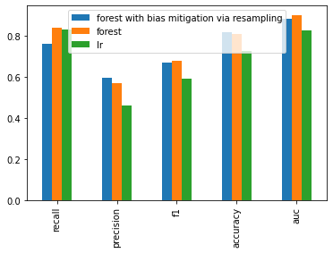

```python
a.plot.bar()
```